# Thesis

Spencer Parr

2024-10-03

# *Spencer Parr Thesis Analysis*

## Info

**Study Overview**:  
The primary objective of this study is to assess the impact of Clionid sponges on coral reef ecosystems in the U.S. Virgin Islands. Coral reefs are critical for biodiversity and marine life, but have faced significant declines due to environmental stressors, including climate change, ocean acidification, and disease outbreaks. Clionid sponges, as bioeroders, contribute to coral degradation by breaking down the calcium carbonate structure of corals, accelerating reef decline. By examining the prevalence and interactions of Cliona sponges with coral over time, this research aims to understand how these sponges influence reef health and resilience, particularly in response to environmental disturbances such as bleaching events and hurricanes.

**Code Explanation**:  
The R scripts provided manage and manipulate TCRMP data, preparing it for statistical analysis. Key steps include filtering Cliona species data, calculating prevalence, and integrating environmental factors. Models such as Linear Mixed-Effects Models (LMEMs) and Generalized Linear Models (GLMs) are applied to assess Cliona recruitment patterns, coral interactions, and environmental influences.

## Metadata

**Coral Health Data**:  
Coral health data is the base structure of the the TCRMP data collection.

## Cliona Prevalence- Coral Health Data

### *This code explains the data management/manipulation and graphical evidence if difference in prevalence for each TCRMP location*

1. The data is read into R using `read_csv`, and then selected columns are extracted, specifically: `Period`, `SampleType`, `Location`, `SampleYear`, `Method`, `Transect`, `SPP`, `Cliona`, `Spo1`, `Spo1ID`, `Spo2ID`, and `Spo2`. This selection reduces the dataset to only the columns relevant to this analysis.
2. Next, a new column called `presence` is created to indicate whether there is evidence of *Cliona* presence on each sample. The `mutate` function is used along with `if_else` to assign a value of `1` to `presence` if any of the following conditions are met: the `Cliona` value is greater than zero, `Spo1ID` or `Spo2ID` columns contain either “CLSP” or “BOSP”. If none of these conditions are met, `presence` is set to `0`. After this, `presence` values are checked for any missing data, and `replace_na` is used to fill any `NA` values with `0`, ensuring that `presence` is either `1` or `0` without any missing values.
3. The code then applies several filters to refine the dataset. First, it filters for rows where `Period` is either “Annual” or “PostBL”, `SampleType` is either “Permanent” or “permanent”, and `Method` is either “intercept” or “50 cm belt”. This step ensures that only specific types of samples are kept for the analysis. Further, rows where `Transect` contains the letter “A” are removed, ensuring that only certain transect data is included. Finally, the code filters for rows where `SampleYear` is 2005 or later, focusing on more recent data.
4. In the last step, additional transformations are applied. A new `ID` column is created to provide a unique identifier for each row, generated as a sequence from `1` to the number of rows in the filtered dataset. The `SampleYear`, `Location`, and `Transect` columns are converted to factor data types using `as.factor` to prepare them for categorical analysis. This finalizes the dataset with all necessary transformations, making it ready for further analysis or modeling.

```r
#1
cliona <- read_csv("../Cliona.csv")%>%
  select(Period,SampleType, Location, SampleYear, Method, Transect, SPP, Cliona, Spo1, Spo1ID, Spo2ID, Spo2)%>%
  #2
  mutate(presence=if_else(Cliona>0 | Spo1ID %in% c("CLSP", "BOSP") | Spo2ID %in% c("CLSP", "BOSP"),1,0))%>%
  mutate(presence=replace_na(presence,0))%>%
  #3
  filter(Period%in% c("Annual","PostBL")&SampleType%in% c("Permanent","permanent")&Method%in% c("intercept","50 cm belt"))%>%
  filter(!grepl("A",Transect))%>%
  filter(SampleYear>=2005)%>%
  #4
  mutate(ID=1:nrow(.),
         SampleYear=as.factor(SampleYear),
         Location=as.factor(Location),
         Transect=as.factor(Transect))
```

5. This R code calculates Cliona sponge prevalence across transects by grouping the `cliona` dataset by `Location`, `SampleYear`, and `Transect`. Within each group, it calculates three metrics: `prev` (the average presence of Cliona, indicating prevalence), `freq` (total occurrences of Cliona), and `total` (total observations in that group). After ungrouping the data, it adds a unique `ID` to each row. The resulting `transectprev` dataset provides summarized prevalence data for each unique combination of location, year, and transect.

```r
transectprev <- cliona %>%
  group_by(Location, SampleYear, Transect) %>%
  summarise(prev = mean(presence), freq = sum(presence), total = n())%>%
  ungroup()%>%
  mutate(ID= 1:nrow(.))
```

6. This code creates a summary data frame, `location_means`, showing the average *Cliona* sponge prevalence for each location. It groups the `transectprev` data by `Location` and then calculates the mean of `prev` (prevalence) within each group, saving the result as `mean_prev`. The resulting `location_means` data frame has each location’s name and its corresponding average *Cliona* prevalence.

```r
location_means <- transectprev %>%
  group_by(Location) %>%
  summarise(mean_prev = mean(prev))
```

7. This code generates a plot that visualizes the prevalence of *Cliona* sponges at different reef sites by creating a boxplot for each location. The `ggplot` function uses the `transectprev` dataset, which contains *Cliona* prevalence data, and arranges the locations on the x-axis in descending order of prevalence. Each boxplot represents the range and distribution of *Cliona* prevalence values at that location. To enhance the visualization, the code includes a `stat_summary` layer that adds a green diamond marker at the mean prevalence for each location, making it easy to compare average *Cliona* prevalence across sites.

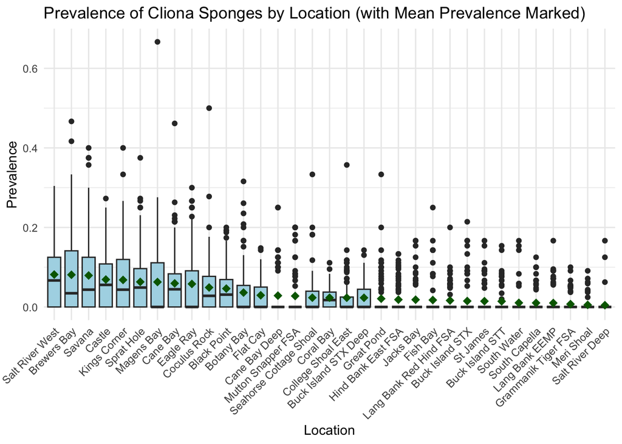

   ```r
   ggplot(transectprev, aes(x = reorder(Location, -prev), y = prev)) +
     geom_boxplot(fill = "lightblue") +
     stat_summary(fun = mean, geom = "point", shape = 18, size = 3, color = "darkgreen") +
     labs(title = "Prevalence of Cliona Sponges by Location (with Mean Prevalence Marked)",
          x = "Location",
          y = "Prevalence") +
     theme_minimal() +
     theme(axis.text.x = element_text(angle = 45, hjust = 1))
   ```

This plot is important because it reveals substantial variability in *Cliona* prevalence across different reef sites. Locations such as Salt River West, Brewers Bay, and Savana show significantly higher prevalence levels, as indicated by both the wider range and higher position of the boxplots and mean markers, compared to other sites with much lower prevalence. This variability suggests that certain sites may be more susceptible to *Cliona* sponge colonization, potentially due to environmental conditions or other factors specific to those areas. Identifying these high-prevalence sites is crucial for targeted reef management and conservation strategies, as it highlights areas where *Cliona* might contribute more heavily to coral degradation.

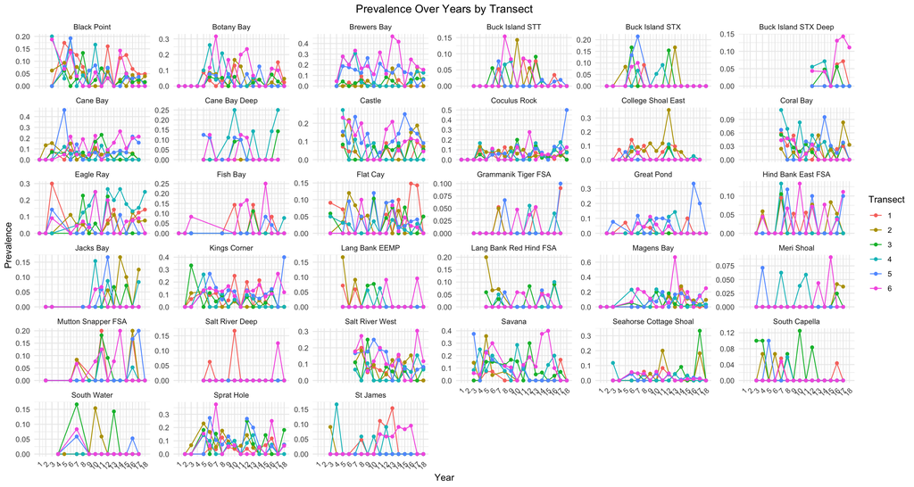

```r
# Convert SampleYear to numeric, if appropriate
transectprev$SampleYear <- as.numeric(transectprev$SampleYear)

# Then plot with the updated variable
ggplot(transectprev, aes(x = SampleYear, y = prev, color = factor(Transect), group = Transect)) +
  geom_line() +
  geom_point() +
  facet_wrap(~Location, scales = "free_y") +
  labs(title = "Prevalence Over Years by Transect",
       x = "Year",
       y = "Prevalence",
       color = "Transect") +
  scale_x_continuous(breaks = unique(transectprev$SampleYear), labels = unique(transectprev$SampleYear)) +
  theme_minimal() +
  theme(axis.text.x = element_text(angle = 45, hjust = 1),
        plot.title = element_text(hjust = 0.5))
```

This graph is valuable because it allows for a detailed temporal analysis of Cliona prevalence trends at multiple scales: across years, transects, and locations. By disaggregating the data by transect and location, the plot can reveal patterns, such as consistent increases or decreases in prevalence, or fluctuations in response to specific events or environmental changes. It’s particularly useful for identifying which transects or locations show higher susceptibility to Cliona over time, offering insights into possible environmental or ecological factors driving these patterns. This information is essential for reef management, as it helps target specific areas or transects that might need more frequent monitoring or interventions to mitigate Cliona spread.

## Substrate Preference

### Ivlev’s Electivity Index

The **Ivlev’s Electivity Index** (Ei) is a quantitative measure used to determine an organism’s preference for certain food or habitat types relative to their availability. In this thesis, it is applied to assess the *Cliona delitrix* sponge’s substrate preferences on coral reefs. Specifically, the index compares the proportion of coral species colonized by Cliona to the proportion of those species available in the environment. A positive Ei value indicates a preference, while negative values suggest avoidance. This helps in understanding how Cliona sponges select coral species under different environmental conditions.

Electivity indices measure the utilization of food types (r) in relation to their abundance or availability in the environment (p). Foods that constitute a larger proportion of the diet than of the available foods are considered preferred; conversely those proportionately underrepresented in the diet are avoided.

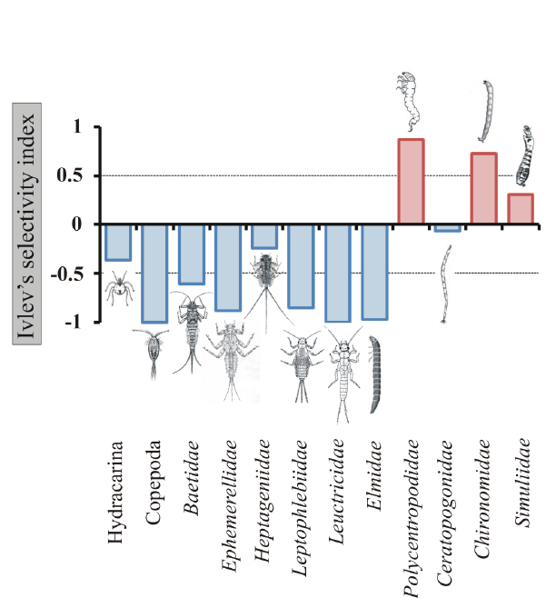

While **Ivlev’s Electivity Index** is typically used for dietary preferences, it can still be effectively applied to *Cliona delitrix* sponges in this thesis, despite corals not being a food source. Cliona sponges exhibit substrate preferences for certain coral species based on factors such as calcium carbonate concentration. Some stony corals have denser calcium carbonate skeletons, which may be harder for Cliona to excavate and colonize. Thus, the sponge’s choice is driven by its ability to grow and obtain necessary nutrients, similar to dietary selectivity in food webs.

```r
# Calculate coral abundance by transect and year
coral_abundance <- cliona %>%
  group_by(SPP, Location, Transect, SampleYear) %>%
  summarise(Abundance = n()) %>%
  ungroup()

clionaclean1 <- cliona %>%
  left_join(coral_abundance, by = c("SPP", "Location", "Transect", "SampleYear"))
```

3. **Summarizing Total Presence and Abundance**:
- The code calculates two key metrics for each coral species (`SPP`). The code creates a summary of each coral species, providing an overall count of how often each species was present and its total abundance across the entire dataset. This allows for a better understanding of the relative presence and prevalence of different coral species in the study area.

```r
# Summarize data to calculate total presence and abundance of each coral species
summary_cliona <- clionaclean1 %>%
  group_by(SPP) %>%
  summarise(TotalPresence = sum(presence),
            TotalAbundance = sum(Abundance)) %>%  # Adjust for coral abundance
  ungroup()
```

- This code calculates the **proportions of presence and availability** for each coral species and then computes **Ivlev’s Electivity Index** to determine whether species are disproportionately present relative to their availability in the environment.

```r
# Calculate proportions and then Ivlev's Electivity Index adjusted for coral abundance
 Ivlev_Index <- summary_cliona %>%
   mutate(ProportionPresence = TotalPresence / sum(TotalPresence),
         ProportionAvailability = TotalAbundance / sum(TotalAbundance),  # Use abundance
          IvlevIndex = (ProportionPresence - ProportionAvailability) /
            (ProportionPresence + ProportionAvailability))

Ivlev_Index %>%
  kable(caption = "Ivlev's Electivity Index Adjusted for Coral Abundance", digits = 4)
```

Ivlev’s Electivity Index Adjusted for Coral Abundance

| SPP | TotalPresence | TotalAbundance | ProportionPresence | ProportionAvailability | IvlevIndex |
| --- | --- | --- | --- | --- | --- |
| AA | 72 | 41794 | 0.0378 | 0.0618 | -0.2408 |
| AC | 0 | 21 | 0.0000 | 0.0000 | -1.0000 |
| AF | 0 | 229 | 0.0000 | 0.0003 | -1.0000 |
| AG | 9 | 1142 | 0.0047 | 0.0017 | 0.4736 |
| AGSP | 3 | 17256 | 0.0016 | 0.0255 | -0.8837 |
| AH | 9 | 10869 | 0.0047 | 0.0161 | -0.5455 |
| AL | 29 | 9780 | 0.0152 | 0.0145 | 0.0259 |
| AP | 0 | 4 | 0.0000 | 0.0000 | -1.0000 |
| AT | 0 | 13 | 0.0000 | 0.0000 | -1.0000 |
| AU | 0 | 41 | 0.0000 | 0.0001 | -1.0000 |
| CN | 7 | 403 | 0.0037 | 0.0006 | 0.7210 |
| DCY | 0 | 60 | 0.0000 | 0.0001 | -1.0000 |
| DL | 7 | 365 | 0.0037 | 0.0005 | 0.7440 |
| DSO | 1 | 58 | 0.0005 | 0.0001 | 0.7193 |
| EF | 0 | 232 | 0.0000 | 0.0003 | -1.0000 |
| FF | 0 | 17 | 0.0000 | 0.0000 | -1.0000 |
| HC | 0 | 1355 | 0.0000 | 0.0020 | -1.0000 |
| IR | 0 | 10 | 0.0000 | 0.0000 | -1.0000 |
| IS | 0 | 4 | 0.0000 | 0.0000 | -1.0000 |
| MAFO | 0 | 62 | 0.0000 | 0.0001 | -1.0000 |
| MAL | 0 | 15 | 0.0000 | 0.0000 | -1.0000 |
| MAN | 0 | 6 | 0.0000 | 0.0000 | -1.0000 |
| MAR | 0 | 25 | 0.0000 | 0.0000 | -1.0000 |
| MC | 87 | 7315 | 0.0457 | 0.0108 | 0.6172 |
| MD | 11 | 2743 | 0.0058 | 0.0041 | 0.1751 |
| MDA | 0 | 3 | 0.0000 | 0.0000 | -1.0000 |
| MDSP | 0 | 33 | 0.0000 | 0.0000 | -1.0000 |
| MF | 1 | 24 | 0.0005 | 0.0000 | 0.8734 |
| MILA | 8 | 4438 | 0.0042 | 0.0066 | -0.2193 |
| MILC | 0 | 702 | 0.0000 | 0.0010 | -1.0000 |
| MILSP | 0 | 4 | 0.0000 | 0.0000 | -1.0000 |
| ML | 0 | 9 | 0.0000 | 0.0000 | -1.0000 |
| MM | 0 | 317 | 0.0000 | 0.0005 | -1.0000 |
| MME | 0 | 793 | 0.0000 | 0.0012 | -1.0000 |
| MP | 0 | 51 | 0.0000 | 0.0001 | -1.0000 |
| MYSP | 0 | 76 | 0.0000 | 0.0001 | -1.0000 |
| OA | 396 | 26709 | 0.2080 | 0.0395 | 0.6808 |
| OFAV | 81 | 5270 | 0.0425 | 0.0078 | 0.6904 |
| OFRA | 166 | 78250 | 0.0872 | 0.1157 | -0.1406 |
| OX | 107 | 38927 | 0.0562 | 0.0576 | -0.0120 |
| PA | 304 | 224707 | 0.1597 | 0.3323 | -0.3509 |
| PB | 0 | 1 | 0.0000 | 0.0000 | -1.0000 |
| PBSP | 2 | 1460 | 0.0011 | 0.0022 | -0.3454 |
| PC | 0 | 116 | 0.0000 | 0.0002 | -1.0000 |
| PCL | 4 | 91 | 0.0021 | 0.0001 | 0.8796 |
| PD | 0 | 413 | 0.0000 | 0.0006 | -1.0000 |
| PF | 1 | 435 | 0.0005 | 0.0006 | -0.1010 |
| PP | 52 | 107932 | 0.0273 | 0.1596 | -0.7078 |
| PS | 26 | 1128 | 0.0137 | 0.0017 | 0.7823 |
| SB | 0 | 8 | 0.0000 | 0.0000 | -1.0000 |
| SC | 0 | 48 | 0.0000 | 0.0001 | -1.0000 |
| SCSP | 0 | 53 | 0.0000 | 0.0001 | -1.0000 |
| SI | 76 | 3601 | 0.0399 | 0.0053 | 0.7646 |
| SL | 0 | 1 | 0.0000 | 0.0000 | -1.0000 |
| SR | 1 | 5785 | 0.0005 | 0.0086 | -0.8843 |
| SS | 444 | 81086 | 0.2332 | 0.1199 | 0.3209 |
| SSPP | 0 | 1 | 0.0000 | 0.0000 | -1.0000 |
| TC | 0 | 1 | 0.0000 | 0.0000 | -1.0000 |
| UNK | 0 | 1 | 0.0000 | 0.0000 | -1.0000 |

5. The resulting graph shows a clear separation at zero, with bars above zero (blue) indicating a preference for certain coral species and bars below zero (red) indicating avoidance. This pattern reveals that Cliona generally avoids many coral species, with only a few species showing a positive electivity index, suggesting that Cliona selectively colonizes specific corals. This insight helps identify coral species that are more vulnerable to Cliona colonization, which is important for managing coral health and understanding Cliona’s ecological impact on reef systems.

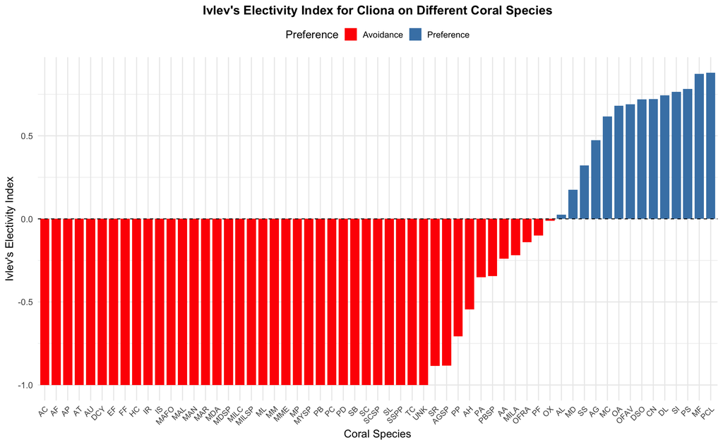

```r
ggplot(Ivlev_Index, aes(x = reorder(SPP, IvlevIndex), y = IvlevIndex, fill = IvlevIndex > 0)) +
  geom_bar(stat = "identity", width = 0.8) +
  labs(title = "Ivlev's Electivity Index for Cliona on Different Coral Species",
       x = "Coral Species",
       y = "Ivlev's Electivity Index") +
  theme_minimal(base_size = 14) +
  scale_fill_manual(values = c("red", "steelblue"),
                    name = "Preference",
                    labels = c("Avoidance", "Preference")) +
  theme(axis.text.x = element_text(angle = 45, hjust = 1, vjust = 1, size = 10),  # Adjust angle and font size
        plot.title = element_text(hjust = 0.5, size = 16, face = "bold"),  # Center and bold title
        legend.position = "top") +  # Move legend to the top
  geom_hline(yintercept = 0, linetype = "dashed", color = "black", size = 0.5)  # Add horizontal line at 0
```